# mSDT: Multi-Item Signal Detection Theory

Colin G. Tredoux

Tamsyn M. Naylor

2026-11-09

> **Acknowledgement.** Large language models supplied by Anthropic and OpenAI were used in preparing this vignette, to assist with checking code, testing the veracity of the approaches described, and on occasion editing the text. Responsibility for the content rests with the authors.

# Overview

This vignette introduces core utilities for the **multi-item signal detection theory (mSDT)** model of Yang, Burke and Healy (2025), covering the components that are mathematically well defined under equal variance and independent filler signals.

```r
library(r4lineups)
```

## What mSDT offers over ordinary SDT

Signal detection theory was built for a **binary** decision: one item is presented, the observer says “old” or “new”, and sensitivity is the separation between two distributions. It works because there is exactly one signal to evaluate against one criterion.

A lineup is not that. The witness sees **m items at once** and has three kinds of response available: identify the suspect, identify a filler, or reject the lineup. Classical SDT has no natural place for the filler identification — it is neither a hit nor a correct rejection — and the usual workarounds either discard filler choices or fold them into an error rate, which throws away the most diagnostic information the lineup produces.

mSDT accommodates them by changing what is modelled. Instead of one signal, it models the **joint distribution of the suspect’s signal and the strongest filler’s signal**. Every response then follows from a single decision rule: if the largest signal in the lineup fails to reach the criterion the witness rejects; otherwise they choose whichever member produced it. Suspect identifications, filler identifications and rejections all fall out of the same model, which is what classical SDT cannot do.

If signal detection theory itself is unfamiliar, the “Signal Detection Theory, briefly” section of `vignette("simulation_power_analysis")` sets out discriminability and criterion without assuming background, and `vignette("sdt_glm_analysis")` shows how the binary case relates to ordinary regression.

The model is set out in full in Yang, Burke and Healy (2025), which is open access — see the References below.

Key components implemented here:

- The **max filler distribution** for $m - 1$ independent standard normal fillers
- **Parameter estimation** from rejection rates in culprit-absent and culprit-present lineups (equivalently, target-absent and target-present)
- **Joint distribution visualisation** (suspect signal against max filler signal)

## Joint distributions, and whether fillers are independent

A **univariate** distribution describes one quantity — how likely the suspect’s signal is to take each value. A **joint** distribution describes two or more together, including how they move with one another.

The distinction is important here because the witness’s decision is not about the suspect’s signal in isolation. It is about whether the suspect’s signal is the largest *and* clears the criterion. That is inherently a question about two quantities at once, so a joint distribution is the natural object.

The models implemented here assume the filler signals are **independent** of one another. That assumption is convenient — it is what makes the max-filler distribution a simple power of the normal CDF — but it is not obviously true. Fillers in a real lineup are chosen to match a description, so they resemble each other. A witness whose memory happens to align with that description may find *all* of them somewhat familiar, and one whose memory does not may find none of them familiar.

The consequence is not small. Under independence the largest of five standard normal fillers has an expected value of about 1.17. If the fillers are strongly correlated the shared component dominates and the *maximum* is much less extreme — around 0.37 at a correlation of 0.9, roughly a third of the independent value. Treating correlated fillers as independent therefore **overstates how often a filler out-competes the suspect**, and so understates the suspect’s exposure.

# Max filler distribution

Because the witness responds to whichever member feels strongest, the quantity that decides the outcome is not any particular filler’s signal but the **largest** of them. So the distribution needed is that of the maximum of $m-1$ filler signals.

Under independence it has a simple closed form. The maximum is below $x$ exactly when every filler is below $x$, so

$$P(\max < x) = \Phi(x)^{m-1}$$

and the density follows by differentiating. This is the whole reason the independence assumption is attractive.

```r
dmax_filler(0, lineup_size = 6)   # density at 0
```

```
#> [1] 0.1246695
```

```r
pmax_filler(0, lineup_size = 6)   # P(max filler < 0) = 0.5^5
```

```
#> [1] 0.03125
```

```r
qmax_filler(0.5, lineup_size = 6) # median of the max filler signal
```

```
#> [1] 1.128998
```

Note that `pmax_filler(0, lineup_size = 6)` is 0.03125, which is $0.5^5$: with five fillers, all five must fall below zero.

The practical point is that the max filler distribution is **shifted well to the right** of the distribution of any single filler. Each filler is centred at 0, but the largest of five is centred near 1.17. A culprit with $d' = 1$ is therefore competing against a typical best-filler signal *higher than its own mean* — which is why lineup identification is hard, and why lineup size is so important.

## Moments

A **moment** is a summary number describing the shape of a distribution. The three used here are the familiar ones under formal names: the first moment is the **mean**, which says where the distribution sits; the second central moment is the **variance**, which says how spread out it is; and the third standardised moment is the **skewness**, which says how asymmetric it is — zero for a symmetric distribution, positive when the right tail is longer.

They are important here because the max filler distribution is **not normal**, even though every filler individually is. Taking a maximum shifts the distribution right, compresses its spread, and makes it asymmetric. The moments quantify exactly that, and they are computed numerically because no simple closed form exists.

```r
moments <- max_filler_moments(6)

knitr::kable(
  data.frame(
    Moment = c("Mean", "Variance", "Skewness"),
    Value  = round(c(moments$mean, moments$var, moments$skewness), 4),
    Reading = c("Centre: well above the 0 of any single filler",
                "Spread: narrower than a single filler's variance of 1",
                "Asymmetry: positive, so a longer right tail")
  ),
  row.names = FALSE,
  caption = "Moments of the maximum of five independent standard normal filler signals (lineup size 6). Analytic quantities, not computed from data."
)
```

Moments of the maximum of five independent standard normal filler signals (lineup size 6). Analytic quantities, not computed from data.

| Moment | Value | Reading |
| --- | --- | --- |
| Mean | 1.1630 | Centre: well above the 0 of any single filler |
| Variance | 0.4475 | Spread: narrower than a single filler’s variance of 1 |
| Skewness | 0.3026 | Asymmetry: positive, so a longer right tail |

# Estimating mSDT parameters from rejection rates

Let

- $\Pr(\mathrm{REJ}\mid I)$ be the rejection rate in culprit-absent lineups
- $\Pr(\mathrm{REJ}\mid G)$ be the rejection rate in culprit-present lineups

Then (Yang et al., 2025):

$$\Pr(\mathrm{REJ}\mid I) = \Phi(\gamma)^m, \qquad
\Pr(\mathrm{REJ}\mid G) = \Phi(\gamma - d')\,\Phi(\gamma)^{m-1}$$

## Why rejection rates in particular

Because they are the one outcome with a clean algebraic form, and between them they identify both parameters.

A rejection occurs only when **every** signal in the lineup falls below the criterion. In a culprit-absent lineup all $m$ members are fillers, so the rejection rate is $\Phi(\gamma)^m$ — and note what is absent from that expression: $d'$. The culprit-absent rejection rate depends on the criterion alone, so it pins $\gamma$ down by itself.

In a culprit-present lineup the culprit must fall below the criterion *and* so must the $m-1$ fillers, giving $\Phi(\gamma - d')\Phi(\gamma)^{m-1}$. With $\gamma$ already known from the first equation, the gap between the two rejection rates fixes $d'$.

Two equations, two unknowns, solved in closed form — no optimiser, no starting values, no convergence to check. That is the appeal.

## What the helper does

`estimate_msdt_params()` is a convenience function that performs that algebra for you: it inverts the first equation for $\gamma$, substitutes into the second, and inverts for $d'$. The two steps are also available separately as `msdt_gamma_from_rej()` and `msdt_dprime_from_rej()`.

```r
params <- estimate_msdt_params(pr_rej_I = 0.25, pr_rej_G = 0.15,
                               lineup_size = 6)
params
```

```
#> $gamma
#> [1] 0.8193286
#>
#> $dprime
#> [1] 0.8789708
```

```r
# The estimate reproduces the input rejection rate exactly, as it must
pnorm(params$gamma)^6
```

```
#> [1] 0.25
```

## What this estimator gives up

The closed form comes at a price.

`estimate_msdt_params()` uses **only the two rejection rates**. It never looks at whether the witnesses who *did* choose picked the suspect or a filler. Since a suspect identification and a filler identification carry very different evidential weight, that is a great deal of information to leave on the table — arguably the most informative part of the data.

The estimator is also **exactly identified**: two numbers in, two parameters out, with nothing left over. There is no residual, so there is no goodness-of-fit test, and for feasible rates the model reproduces the two rates it was given. Not every pair of rates is feasible, however. With $m$ members, a target-absent rejection rate $r_A$ fixes $\gamma$, and the target-present rejection rate can then be at most $r_A^{(m-1)/m}$, the limit as $d' \to -\infty$. Rates outside that bound, for example `estimate_msdt_params(0.1, 0.9, 6)`, are rejected with an error, and rates at the edges of the scale are clipped, so the reproduction is exact only in the interior.

Use it when the rejection rates are all you have, or as a quick starting point. Where the full response breakdown exists, prefer:

| Function | Uses | Gives you |
| --- | --- | --- |
| `estimate_msdt_params()` | Two rejection rates | $\gamma$ and $d'$, closed form, no fit statistic |
| `fit_max_sdt()` | All suspect/filler/reject counts | $d'$ and criterion, plus a chi-square goodness-of-fit and bootstrap intervals |
| `fit_winter_2ht()` | All suspect/filler/reject counts | A different process account, separating detection from guessing and bias |

`fit_max_sdt()` fits the same MAX decision rule as here, on the compound decision structure described by Duncan (2006), by minimising Pearson chi-square rather than maximising a likelihood. See `vignette("model_comparison")` for the 2-HT alternative.

# Joint distribution plots

These show the decision space directly: the suspect’s signal on one axis, the strongest filler’s signal on the other. The MAX rule carves that plane into three regions — reject, identify the suspect, identify a filler — and the contours show where the probability mass falls in each.

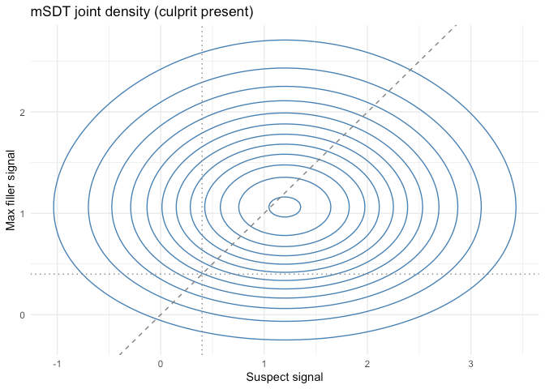

```r
plot_msdt_joint(dprime = 1.2, gamma = 0.4, lineup_size = 6,
                lineup_type = "culprit_present")
```

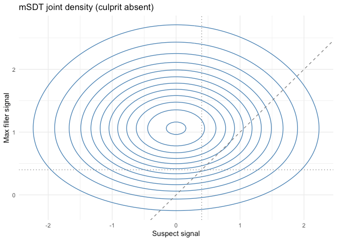

```r
plot_msdt_joint(dprime = 1.2, gamma = 0.4, lineup_size = 6,
                lineup_type = "culprit_absent")
```

**These plots use no dataset.** They are analytic densities drawn from the parameters supplied in the call — here $d' = 1.2$, $\gamma = 0.4$ and a six-person lineup — not summaries of observed data. Comparing the two makes the model’s logic visible. In the culprit-absent plot the suspect is one innocent member, Normal(0, 1), but the other axis is the **strongest of the five fillers**, whose density is $5\phi(m)\Phi(m)^4$ with mean about 1.16. The joint density $\phi(s) \cdot 5\phi(m)\Phi(m)^4$ is therefore not symmetric about the diagonal: the mass sits above it, towards the filler axis (at $(s, m) = (0, 1)$ the density is about eight times that at $(1, 0)$). That asymmetry is why an innocent suspect is chosen less often than the fillers combined. In the culprit-present plot the suspect’s signal is shifted by $d'$, moving the mass towards the suspect axis.

# Technical Details

## What is computed

| Function | Quantity | Form |
| --- | --- | --- |
| `dmax_filler()` | Density of the max of $m-1$ fillers | $(m-1)\phi(x)\Phi(x)^{m-2}$ |
| `pmax_filler()` | CDF | $\Phi(x)^{m-1}$ |
| `qmax_filler()` | Quantile | $\Phi^{-1}(p^{1/(m-1)})$ |
| `max_filler_moments()` | Mean, variance, skewness | Numerical integration |
| `estimate_msdt_params()` | $\gamma$, $d'$ | Closed form from the two rejection rates |

## Assumptions

1. Filler signals are independent and identically distributed $N(0, 1)$.
2. The culprit signal is $N(d', 1)$ — equal variance.
3. A single criterion $\gamma$ is applied to the largest signal, with no confidence criteria.
4. Lineups are simultaneous and fair, so `lineup_size` counts **functioning** alternatives. A lineup with null foils has a smaller effective size than its nominal size, and since $m$ enters the equations directly, both $\gamma$ and $d'$ will be biased. Check `lineup_table()` first.
5. `estimate_msdt_params()` is exactly identified and therefore untestable — no residual, no goodness-of-fit.

# References

Duncan, M. (2006). *A signal detection model of compound decision tasks* (Technical Note DRDC TR 2006-256). Defence R&D Canada, Toronto.

Wixted, J. T., Vul, E., Mickes, L., & Wilson, B. M. (2018). Models of lineup memory. *Cognitive Psychology, 105*, 81-114.

Yang, Y., Burke, J. L., & Healy, J. (2025). A multi-item signal detection theory model for eyewitness identification. *Cognitive Research: Principles and Implications, 10*, 54. https://doi.org/10.1186/s41235-025-00652-3

# Further Reading

- `?dmax_filler`, `?estimate_msdt_params`, `?plot_msdt_joint`, `?fit_max_sdt`
- `vignette("simulation_power_analysis")` for signal detection theory from the beginning
- `vignette("model_comparison")` and `vignette("lineup_memory_models")` for the models that use the full response breakdown